# Acoustic freeform lab — first forward reference

**Research endpoint:** shape a liquid resin interface using a coherent array, eventually preserve it by curing, and assess the resulting optic. This notebook implements and interrogates the first small-deformation forward reference. It does not model resin chemistry, a finite lens, or optical performance yet.

The two examples are a water–air wave check and an idealized viscous liquid pair. Neither is a fitted reproduction of a published experiment. Their purpose is to establish transparent equations, independent checks, and useful visual tools.

```python
from pathlib import Path

import matplotlib.pyplot as plt
import numpy as np

from acoustic_freeform.config import load_experiment
from acoustic_freeform.simulation import load_result, run

ROOT = Path.cwd() if (Path.cwd()/"src").is_dir() else Path.cwd().parent
config = load_experiment(ROOT/"examples/water_air.toml")
run_dir = ROOT/"runs/water_air_v1"
result = load_result(run_dir) if (run_dir/"result.npz").exists() else run(config)
print(config.description)
print(config.material_status)
print(f"Array: {config.array.nx} × {config.array.ny} individually weighted pressure patches")
print(f"Box: {config.grid.lx_m*1000:g} mm; observation: {config.timing.end_s*1000:g} ms")
```

```
A coherent 256-element array creates a non-axisymmetric double focus. Two smooth pulses expose capillary memory.
Representative room-temperature water/air benchmark constants; not a calibrated resin and not an experimental reproduction.
Array: 16 × 16 individually weighted pressure patches
Box: 56 mm; observation: 60 ms
```

## 1. What the apparatus means here

A 16 × 16 array lies at $z=-H$, beneath a nominal interface at $z=0$. Each square patch has a complex outgoing pressure weight $w_j$. The example derives these weights from two displaced foci; arbitrary complex element weights can also be supplied to `run(config, element_weights=...)`. This exposes all 256 controls without claiming arbitrary shapes are reachable.

**Source convention:** pressure phasors are **peak amplitudes**, with physical pressure $p'(\mathbf{x},t)=\Re[P(\mathbf{x})e^{-i\omega t}]$. Electrical power, piezo displacement, and total face velocity are different inputs and require a transducer model. The source plane absorbs returning sound. It is not a no-slip lower wall in the hydrodynamic model: both slow fluids are deep half-spaces. Thus $H$ is the acoustic gap, not the liquid-layer thickness.

For source area $A=L_xL_y$ and patch width $d$, exact Fourier coefficients are

$$\widehat P_s(\mathbf{k})=\frac{p_0 d^2}{A} \operatorname{sinc}(k_xd/2)\operatorname{sinc}(k_yd/2) \sum_j w_j e^{-i\mathbf{k}\cdot\mathbf{x}_j},$$

where $\operatorname{sinc}(u)=\sin(u)/u$. No pixelated aperture mask is used.

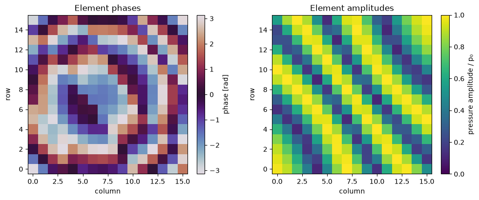

```python
weights = result.element_weights[0]
fig, ax = plt.subplots(1, 2, figsize=(10, 4), layout="constrained")
im = ax[0].imshow(np.angle(weights), origin="lower", cmap="twilight", vmin=-np.pi, vmax=np.pi)
fig.colorbar(im, ax=ax[0], label="phase [rad]")
im = ax[1].imshow(np.abs(weights), origin="lower", cmap="viridis", vmin=0, vmax=1)
fig.colorbar(im, ax=ax[1], label="pressure amplitude / p₀")
for a, title in zip(ax, ["Element phases", "Element amplitudes"], strict=True):
    a.set(xlabel="column", ylabel="row", title=title)
plt.show()
```

## 2. Acoustic propagation and reflection

Let $k_{zi}=\sqrt{(\omega/c_i)^2-k_x^2-k_y^2}$ with nonnegative imaginary part. For normal velocity admittance $Y_i=k_{zi}/(\omega\rho_i)$,

$$R=\frac{Y_1-Y_2}{Y_1+Y_2},\qquad T=1+R,\qquad \widehat P_I=\widehat P_s e^{ik_{z1}H}.$$

Pressure and normal acoustic velocity are continuous at the interface. For the lower fluid, $P=P_I+P_R$ and $V_z=k_{z1}(P_I-P_R)/(\omega\rho_1)$; the reflected velocity has the opposite normal sign. Transverse components follow the pressure gradient.

The acoustic interface stays flat in this reference. The default retains only propagating incident modes; evanescent source terms decay strongly over this gap. The independent Rayleigh-integral comparison in notebook 02 measures the combined effect of this omission and periodic replicas at prespecified pressure probes.

## 3. Radiation traction is not just surface pressure squared

For a flat normal $\mathbf{n}=\mathbf{e}_z$, define the normal momentum flux

$$M_{nn,i}=\frac{|P_i|^2}{4\rho_i c_i^2} +\frac{\rho_i}{4}\left(|V_{zi}|^2-|V_{xi}|^2-|V_{yi}|^2\right),\qquad \Pi=M_{nn,1}-M_{nn,2}.$$

Positive $\Pi$ drives upward displacement. This is the peak-phasor form of the radiation tensor in [Chesneau et al. (2022), Eqs. 9–14](https://doi.org/10.1103/PhysRevE.106.065104). For a pressure-release limit, the total pressure at the surface approaches zero, but the acoustic velocity and radiation force do not. A pressure-only shortcut therefore fails even in a simple limiting case.

Coherent beams satisfy $P=\sum_b a_b(t)P_b$, so $\Pi=\sum_{bc}a_b(t)a_c(t)K_{bc}$. The cross terms are retained. These envelopes are real; all fixed relative acoustic phases are in the complex beam weights.

```
Integrated acoustic powers [W]: {'incident': 0.00047268828923968355, 'reflected': 0.00047224268214159456, 'transmitted': 4.456070980888938e-07, 'lower_net': 4.4560709808888805e-07, 'evanescent_interference': -1.0842021724855044e-19}
Relative flux balance: 2.0495407977642214e-16
```

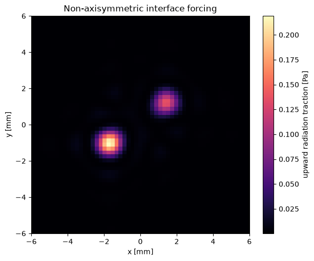

```python
peak_drive = int(np.argmax(np.sum(result.amplitudes**2, axis=1)))
solution = result.acoustic_model.solve(
    result.pressure_array.spectrum(result.combined_weights(peak_drive))
)
powers = solution.powers_w
print("Integrated acoustic powers [W]:", powers)
print("Relative flux balance:", abs(powers["incident"]-powers["reflected"]-powers["transmitted"])
      / powers["incident"])
g = result.grid
crop = np.flatnonzero(np.abs(g.x) <= .006)
fig, ax = plt.subplots(figsize=(6, 5), layout="constrained")
im = ax.pcolormesh(g.x[crop]*1000, g.y[crop]*1000,
                   result.pressure(peak_drive)[np.ix_(crop, crop)], shading="auto", cmap="magma")
fig.colorbar(im, ax=ax, label="upward radiation traction [Pa]")
ax.set(xlabel="x [mm]", ylabel="y [mm]", aspect="equal", title="Non-axisymmetric interface forcing")
plt.show()
```

## 4. Two explicit hydrodynamic limits

For each nonzero transverse wavenumber $k=|\mathbf{k}|$, the linear restoring stiffness per area is $S_k=\sigma k^2+(\rho_1-\rho_2)g$. The Fourier zero mode is held at zero: the periodic cell conserves liquid volume. A uniform pressure reaction balances the mean acoustic traction.

**Weakly damped liquid under a light gas:**

$$m_k\ddot{\hat h}+2\gamma_km_k\dot{\hat h}+S_k\hat h=\hat\Pi, \qquad m_k=\frac{\rho_1+\rho_2}{k},\quad\gamma_k=2\nu_1k^2.$$

This has the inviscid capillary–gravity dispersion $\omega_k^2=[(\rho_1-\rho_2)gk+\sigma k^3]/(\rho_1+\rho_2)$. The damping is a weak-viscosity approximation; gas drag and the full transient viscous boundary layer are omitted. It must not be reused as a general viscous two-liquid model. [Denner (2016)](https://doi.org/10.1103/PhysRevE.94.023110) examines the limitations of customary damping descriptions when viscosity matters.

**Deep two-fluid Stokes limit:**

$$2(\mu_1+\mu_2)k\dot{\hat h}+S_k\hat h=\hat\Pi.$$

One way to derive its mobility is to solve the biharmonic Stokes problem with normal interface speed $W=\dot{\hat h}$. The decaying solutions are $w_1=(1-kz)e^{kz}W$ below and $w_2=(1+kz)e^{-kz}W$ above. Incompressibility gives $\mathbf{u}_{\parallel,i}=-i\mathbf{k}z e^{-k|z|}W$. The normal viscous traction jump is $2(\mu_1+\mu_2)kW$, giving the equation above. This is the zero-inertia limit, not a fitted interpolation into the wave model.

Constant forcing is integrated exactly mode by mode. Smooth pulse envelopes are sampled at each step midpoint, so forcing integration is second order. The saved height/normal-speed arrays are float32; integration and diagnostics use float64. This distinction is recorded in each report.

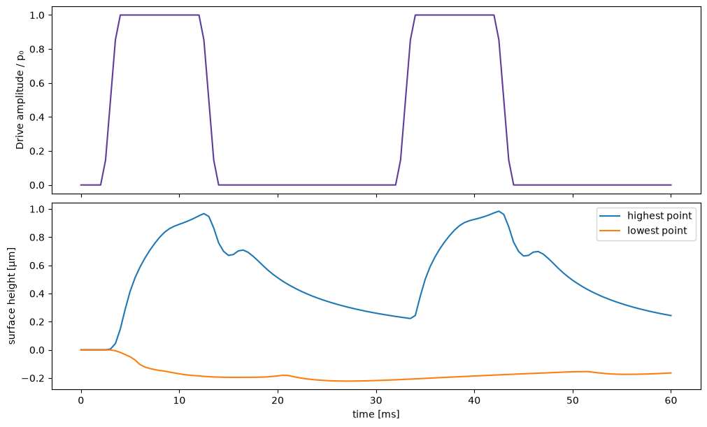

```python
fig, axes = plt.subplots(2, 1, figsize=(10, 6), sharex=True, layout="constrained")
t_ms = result.time_s*1000
axes[0].plot(t_ms, result.amplitudes[:, 0], color="#5e3c99")
axes[0].set_ylabel("Drive amplitude / p₀")
axes[1].plot(t_ms, result.metrics["max_height_m"]*1e6, label="highest point")
axes[1].plot(t_ms, result.metrics["min_height_m"]*1e6, label="lowest point")
axes[1].set(xlabel="time [ms]", ylabel="surface height [µm]")
axes[1].legend()
plt.show()
```

## 5. Same instantaneous input, different surface

At 10 ms and 40 ms the array has the same weights and full pulse amplitude. Both times are 8 ms after a pulse began. The second surface still contains motion excited by the first pulse. This is hydrodynamic state dependence. In this *linear* reference it can be represented by a convolution or state-space model; this observation alone does not establish a hard inverse problem. No chemical memory, viscoelastic memory, thermal history, or nonlinear hysteresis has been implemented. Those require separate physical models and evidence.

```
Same drive amplitudes: [1.]
Difference in central surface: RMS=0.11019 µm
```

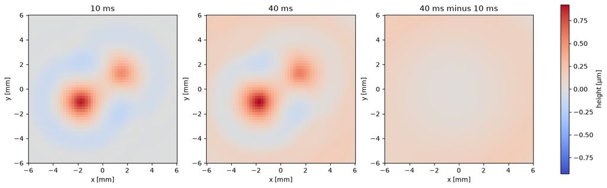

```python
i1 = int(np.argmin(abs(result.time_s-.010)))
i2 = int(np.argmin(abs(result.time_s-.040)))
assert np.array_equal(result.amplitudes[i1], result.amplitudes[i2])
assert np.allclose(result.pressure(i1), result.pressure(i2))
h1, h2 = [result.height_m[i][np.ix_(crop, crop)]*1e6 for i in (i1, i2)]
print(f"Same drive amplitudes: {result.amplitudes[i1]}")
print(f"Difference in central surface: RMS={np.sqrt(np.mean((h2-h1)**2)):.5f} µm")
fig, axes = plt.subplots(1, 3, figsize=(13, 4), layout="constrained")
bound = max(np.max(np.abs(h1)), np.max(np.abs(h2)), np.max(np.abs(h2-h1)))
for ax, h, title in zip(axes, [h1, h2, h2-h1], ["10 ms", "40 ms", "40 ms minus 10 ms"], strict=True):
    im = ax.pcolormesh(g.x[crop]*1000, g.y[crop]*1000, h, cmap="coolwarm",
                       vmin=-bound, vmax=bound, shading="auto")
    ax.set(xlabel="x [mm]", ylabel="y [mm]", aspect="equal", title=title)
fig.colorbar(im, ax=axes, label="height [µm]")
plt.show()
```

## 6. PyVista surface and physical field exports

Below is a newly rendered surface, not a sketch. Its horizontal geometry is in millimetres, height color in micrometres, and vertical geometry exaggerated by 1800 for legibility. The VTK files exported by `lenslab render` instead contain **metres, pascals and metres/second, with no geometric exaggeration**.

For the live time slider, run `uv run lenslab view runs/water_air_v1` in the repo. `visuals/explore.html` offers camera interaction for a static time snapshot; `visuals/evolution.mp4` shows time evolution. The pressure-array panel in the dashboard is a fixed peak-drive reference, while the other panels evolve.

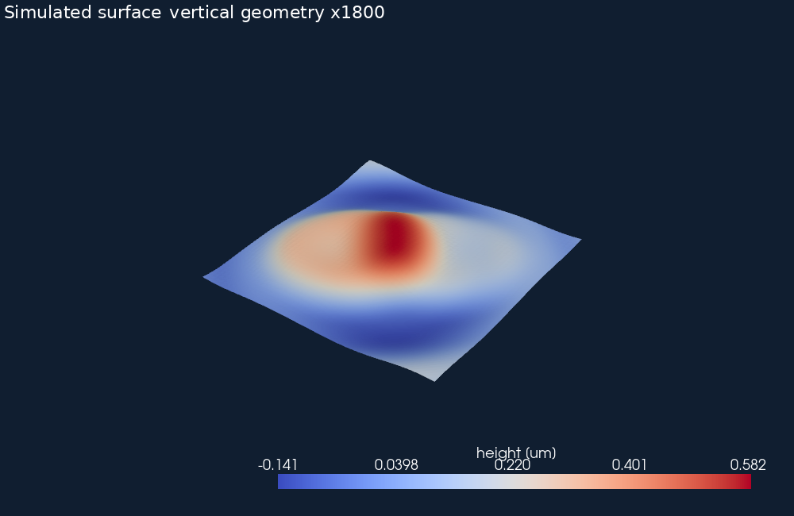

```python
import pyvista as pv
from IPython.display import display
from PIL import Image

frame = int(np.argmax(result.metrics["rms_height_m"]))
h = result.height_m[frame][np.ix_(crop, crop)]
xx, yy = np.meshgrid(g.x[crop]*1000, g.y[crop]*1000)
surface = pv.StructuredGrid(xx.T, yy.T, (h*1000*1800).T)
surface["height [um]"] = h.ravel()*1e6
plotter = pv.Plotter(off_screen=True, window_size=(1000, 650))
plotter.set_background("#101e30")
plotter.add_mesh(surface, scalars="height [um]", cmap="coolwarm",
                 scalar_bar_args={"color": "white"})
plotter.add_text("Simulated surface | vertical geometry x1800", color="white", font_size=13)
plotter.camera_position = [(20, -28, 24), (0, 0, 0), (0, 0, 1)]
plotter.show(auto_close=False, interactive=False)
preview = plotter.screenshot(return_img=True)
plotter.close()
display(Image.fromarray(preview))
```

## 7. What still separates this reference from a lens experiment

The calculation supports arbitrary *inputs* and non-axisymmetric surfaces. It does not guarantee arbitrary *target shapes*. Finite aperture, diffraction, traction sign, capillary smoothing, fluid volume and stability restrict reachability.

The first decisive extensions are finite fluid geometry and wave scattering from the evolving interface. [Bertin et al. (2012)](https://doi.org/10.1103/PhysRevLett.109.244304) and [Chesneau et al. (2022)](https://doi.org/10.1103/PhysRevE.106.065104) motivate the latter for larger deformations. Our tiny values of slope and $k h$ only support using this as an initial small-deformation check; they are not an experimental error bound.

[Sisombat et al. (2023)](https://doi.org/10.1038/s41598-023-39464-0) is a useful experimental anchor for pulse-driven interface deformation, with a different rig. [Gu et al. (2020)](https://doi.org/10.1021/acsnano.0c03754) motivates spatial patterning and attention to streaming, but does not establish an optical resin process. [Elgarisi et al. (2021)](https://doi.org/10.1364/OPTICA.438763) and [Na et al. (2024)](https://doi.org/10.1145/3680528.3687584) connect fluidic shaping to cured optics. Their methods do not validate this acoustic simulator.

Before adding curing, choose a resin/bath pair with measured viscosity, density, acoustic speed/attenuation and surface tension. Then determine which omitted mechanisms materially affect the experimental times and length scales.